# About me

2023-10-05T21:05:33+05:30

#### [Resume](https://drive.google.com/file/d/18ovFEgYAbvRgCV6bSXoh5qDJXX_6cfYU/view?usp=sharing)

#### Cover Letter

My greatest love is my pack of rescue dogs. My second greatest love is turning data into useful insights and actions.

In my current position as a Data Analyst III in the Assessor’s Office for Utah County Government, I have created R Shiny applications to review land district boundaries and statistical analyses to analyze and update/combine current boundaries. I am also team lead in charge of creating a new valuation process for assessing land values for Utah County, UT.

In this position, I have used R Markdown to document all current and upcoming processes for interacting with the office’s newly created applications and land valuation process. I have also created specific documentation for the metadata of our office’s databases (Oracle and Azure), as well as documentation for many large scale processes and reports for the office.

As a Performance Marketing Analyst, I prepared weekly auditing reports to review all data that was received via our lead generation channels. After the data was audited and any discrepancies corrected, I created dashboards that provide a daily reference to track our lead information over time. I also used other external data sources to create statistical analyses and predictions to assist team members in streamlining their marketing campaigns to better reach their audiences.

As a Data Operations Consultant for Filevine, I routinely worked with stakeholders to analyze, clean, transform, and organize data using Excel and R in order to migrate their data into their Filevine or Lead Docket environment. Clients and I were in constant collaboration to not only find the correct data, but also to correct and organize their data into an easily readable and usable format.

In my previous employment as a data analyst at Utah Valley University, and employment as a teacher and researcher, I have been required to utilize technology resources including university databases, Oracle, SQL, R, and digital libraries to facilitate organizational research. I assisted various university departments in using Oracle, SQL, Excel, and Tableau to answer questions about department and student success, visualize the learning outcomes of a variety of courses and degrees, and analyze student performance. I also used R to statistically locate and visualize predictors of academic success at Utah Valley University as well as created a Shiny application to make the University College data entry process more efficient.

With my approximately 7 years of experience in data organization and data analysis roles, I acquired a background in problem solving, employee training, and collaborative group work as well as solo projects.

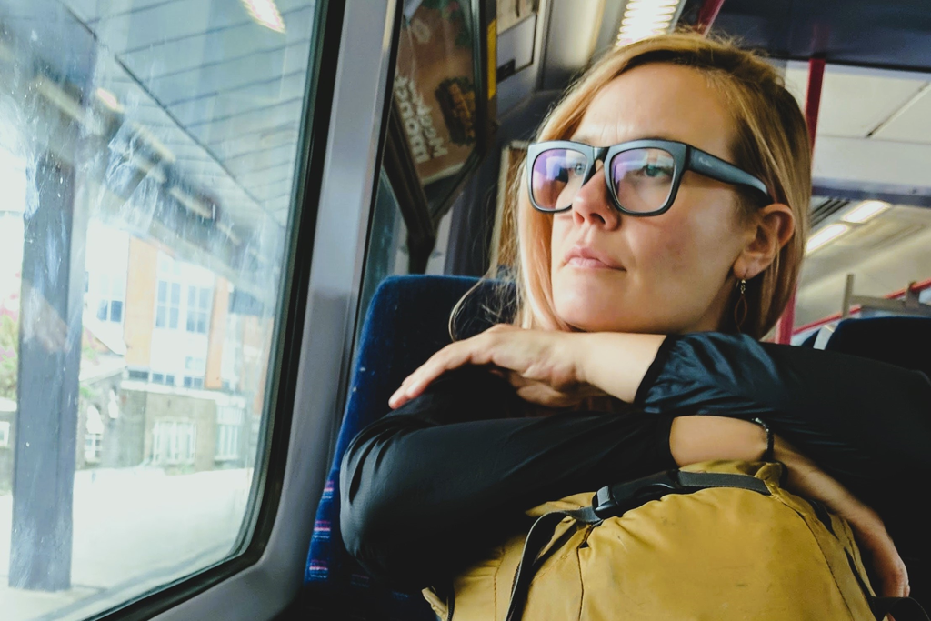

This is me

#### Education

- BS Information Systems, Utah Valley University
- MA, English/Composition Rhetoric, Missouri State University
- Certificate of Proficiency - Data Analysis, Utah Valley University
- Certificate of Proficiency - Data Management/Database Administration, Utah Valley University
- Certificate of Proficiency - Information Technology, Utah Valley University